# Additional R material

Optional self-study content for weeks 12-13

Author

Affiliations

Jelmer Poelstra

[CFAES Bioinformatics Core, Ohio State University](https://go.osu.edu/bioinformatics-core)

[Dept. of Plant Pathology, Ohio State University](https://plantpath.osu.edu)

Published on

November 9, 2026

Page last modified

October 17, 2026

## 1 Introduction

This page contains additional R material that builds on the week 12 self-study section on vectors and data types and the week 13 lectures on data wrangling and visualization.

## 2 Vectors

### 2.1 Sequences of numbers with `seq()`

The `:` operator makes series of whole numbers with steps of 1. For finer control, use the `seq()` function and its arguments `from` (start value), `to` (end value), and `by` (step size):

```r
stepwise_vec <- seq(from = 6, to = 8, by = 0.2)
stepwise_vec
```

```
 [1] 6.0 6.2 6.4 6.6 6.8 7.0 7.2 7.4 7.6 7.8 8.0
```

### 2.2 Exploring vectors

R has many functions that provide information about vectors and other types of objects, such as:

- Get the **number of elements** with `length()`:

  ```r
  length(stepwise_vec)
  ```

  ```
  [1] 11
  ```

- See the **first and last few elements**, respectively, with `head()` and `tail()`:

  ```r
  # Print the first 6 elements:
  head(stepwise_vec)
  ```

  ```
  [1] 6.0 6.2 6.4 6.6 6.8 7.0
  ```

  ```r
  # Print the last 6 elements:
  tail(stepwise_vec)
  ```

  ```
  [1] 7.0 7.2 7.4 7.6 7.8 8.0
  ```

  ```r
  # Both head and tail have argument `n` to specify the number of elements:
  tail(stepwise_vec, n = 2)
  ```

  ```
  [1] 7.8 8.0
  ```

- Get **arithmetic summaries** like `mean()` for vectors with numbers:

  ```r
  # mean() will compute the mean (average) across all elements
  mean(stepwise_vec)
  ```

  ```
  [1] 7
  ```

### 2.3 Changing vector elements: more examples

You can use functions inside the brackets and on the right side of the assignment arrow:

- Change the last element to `0`:

  ```r
  stepwise_vec[length(stepwise_vec)] <- 0
  stepwise_vec
  ```

  ```
   [1] 6.0 6.2 6.4 6.6 6.8 7.0 7.2 7.4 7.6 7.8 0.0
  ```

- Change the second element to the mean value of the vector:

  ```r
  stepwise_vec[2] <- mean(stepwise_vec)
  stepwise_vec
  ```

  ```
   [1] 6.000000 6.272727 6.400000 6.600000 6.800000 7.000000 7.200000 7.400000
   [9] 7.600000 7.800000 0.000000
  ```

#### Exercise: Vectors

Make a vector `x` with the whole numbers 1 through 26. Then, subtract 0.5 from each element in `x` and save the result in vector `y`. Check your results by printing both vectors.

**Click to see the solution**

```r
x <- 1:26
x
```

```
 [1]  1  2  3  4  5  6  7  8  9 10 11 12 13 14 15 16 17 18 19 20 21 22 23 24 25
[26] 26
```

```r
y <- x - 0.5
y
```

```
 [1]  0.5  1.5  2.5  3.5  4.5  5.5  6.5  7.5  8.5  9.5 10.5 11.5 12.5 13.5 14.5
[16] 15.5 16.5 17.5 18.5 19.5 20.5 21.5 22.5 23.5 24.5 25.5
```

## 3 Factors

### 3.1 Oddly, factors are technically not a data type

In week 13, you saw how to use factors to store categorical data with a custom order. For most intents and purposes, it makes sense to think of factors as another data type, even though technically, they are a kind of data structure built on the `integer` data type:

```r
diet_fct <- factor(c("high", "medium", "low"), levels = c("low", "medium", "high"))
typeof(diet_fct)
```

```
[1] "integer"
```

## 4 Plotting with *ggplot2*

These sections build on the week 13 data visualization lecture, and use the same packages:

```r
library(tidyverse)
library(palmerpenguins)
```

### 4.1 Color palettes

What if you have 10 treatments that you want to color? Picking all colors manually with `scale_color_manual()` requires a lot of typing. Instead, you can use ready-made **color palettes**, such as those from the *RColorBrewer* package, which is installed along with *ggplot2*:

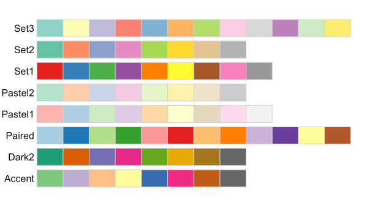

For example, to use the `Pastel1` palette for a scatter plot, use the function `scale_color_brewer()`:

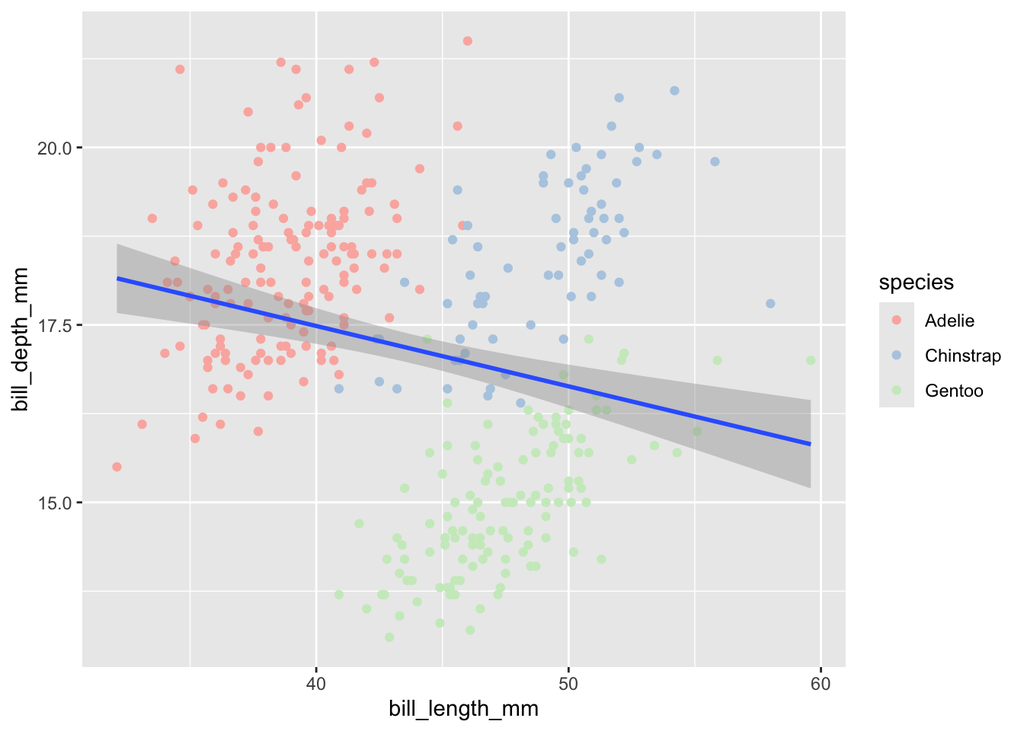

```r
penguins |>
  ggplot(aes(x = bill_length_mm, y = bill_depth_mm)) +
  geom_point(aes(color = species)) +
  scale_color_brewer(palette = "Pastel1") +
  geom_smooth(method = "lm")
```

### 4.2 Customizing themes

Besides applying a pre-defined theme like `theme_bw()`, you can change individual theme elements with the `theme()` function. For example, to change the text size of the plot title and axes, and the position of the legend:

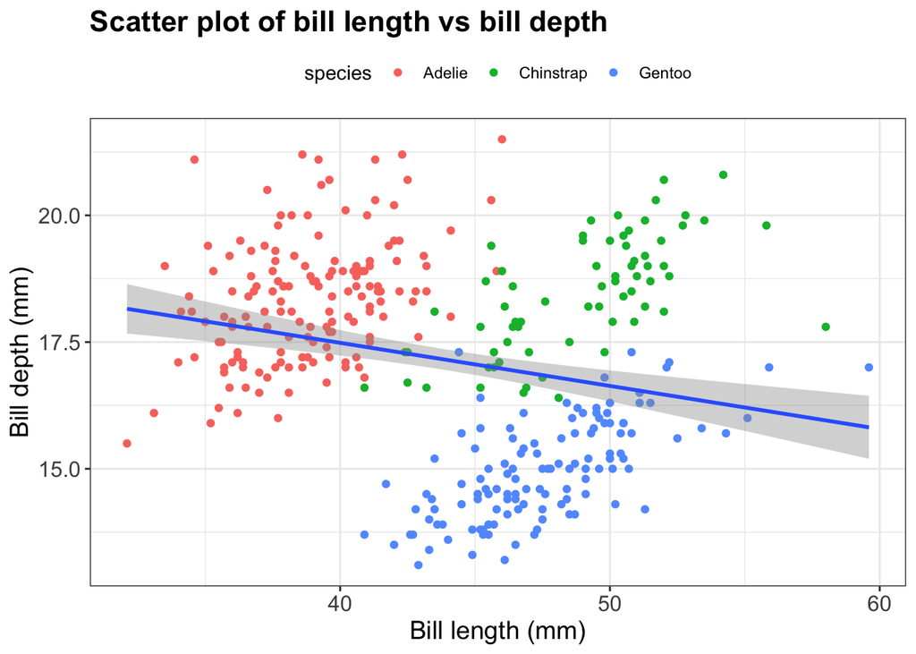

```r
penguins |>
  ggplot(aes(x = bill_length_mm, y = bill_depth_mm)) +
  geom_point(aes(color = species)) +
  geom_smooth(method = "lm") +
  labs(
    title = "Scatter plot of bill length vs bill depth",
    x = "Bill length (mm)",
    y = "Bill depth (mm)"
  ) +
  theme_bw() +
  theme(
    plot.title = element_text(size = 16, face = "bold"),
    axis.title = element_text(size = 14),
    axis.text = element_text(size = 12),
    legend.position = "top"
  )
```

Back to top